# Projet GMM5 2017

## PLS-DA on `Coronavirus`

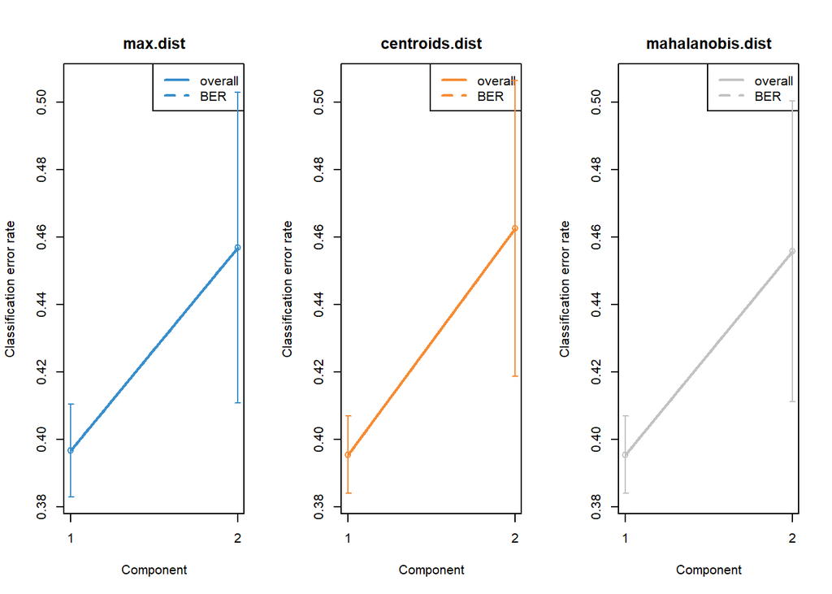

```r
set.seed(11)
res_plsda <- plsda(X=clean_log,Y=Y$Ct.Coronavirus, ncomp = nlevels(clean_condition))
res_perf <- perf(res_plsda, validation = 'Mfold', folds = 5,
                 progressBar = FALSE, nrepeat = 20)
plot(res_perf, overlay = 'measure', sd = TRUE)
```

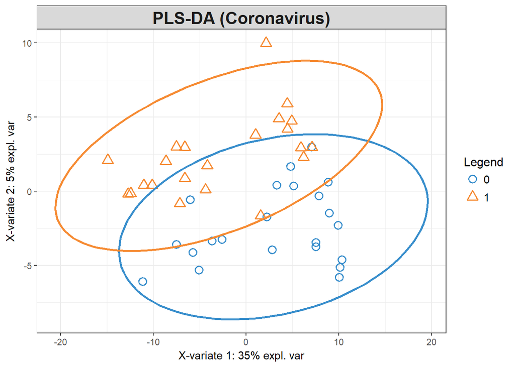

```r
plotIndiv(res_plsda , comp = c(1, 2), ind.names = FALSE, ellipse = TRUE,
          legend = TRUE, title = 'PLS-DA (Coronavirus)')
```

```r
set.seed(33)
res_plsda <- tune.splsda(X=clean_log,Y=Y$Ct.Coronavirus,
                         ncomp = nlevels(clean_condition),
                         multilevel = clean_id,
                         test.keepX = 1:20, validation = 'Mfold',
                         folds = 10, dist = 'mahalanobis.dist', nrepeat = 10,
                         progressBar = F)
```

```
## Splitting the variation for 1 level factor.
```

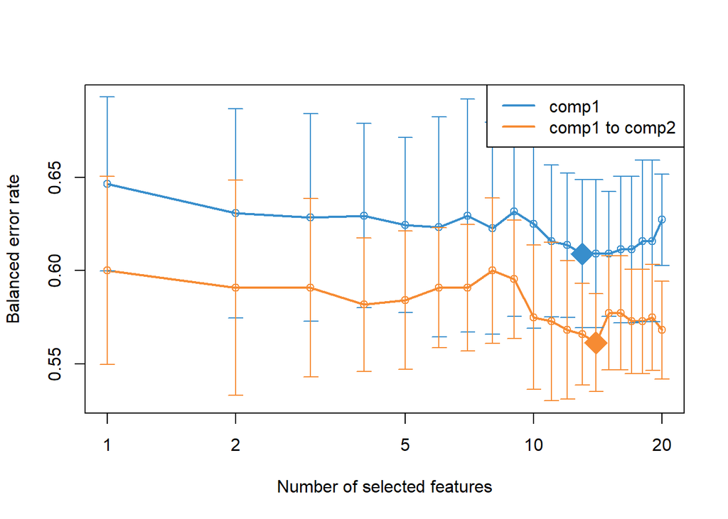

```r
plot(res_plsda)
```

```r
sel_keepX <- res_plsda$choice.keepX[1:2]
sel_keepX
```

```
## comp1 comp2
##    13    14
```

```r
res_splsda <- splsda(X=clean_log,Y=Y$Ct.Coronavirus,
                     ncomp = nlevels(clean_condition),
                     multilevel = clean_id,
                     keepX = sel_keepX)
```

```
## Splitting the variation for 1 level factor.
```

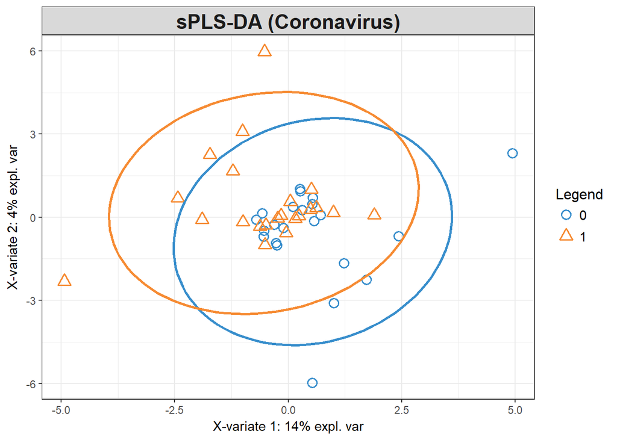

```r
plotIndiv(res_splsda, comp = c(1,2), ind.names = FALSE, ellipse = TRUE,
          legend = TRUE, title = 'sPLS-DA (Coronavirus)')
```

Si on limite le nombre de variables, on n’arrive pas a discrimner de maniere lineaire la presence ou l’absence du Coronavirus.

```r
head(selectVar(res_splsda, comp = 1)$name)
```

```
## [1] "Alcaligenes sp."            "Moraxella lacunata"
## [3] "Bacteroides"                "Prevotella 7"
## [5] "Streptococcus gallolyticus" "Mycoplasma dispar"
```

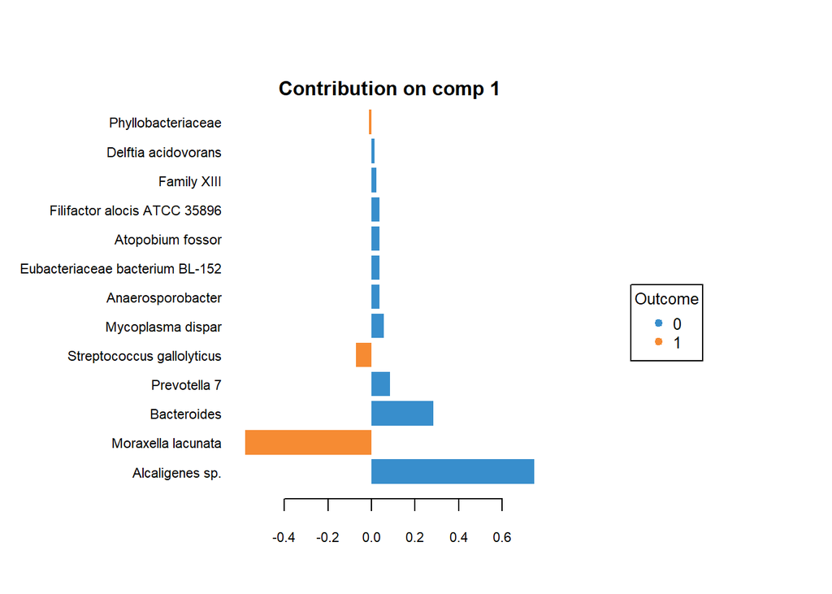

```r
plotLoadings(res_splsda, comp = 1, method = 'mean', contrib = 'max',
             size.title = 1)
```

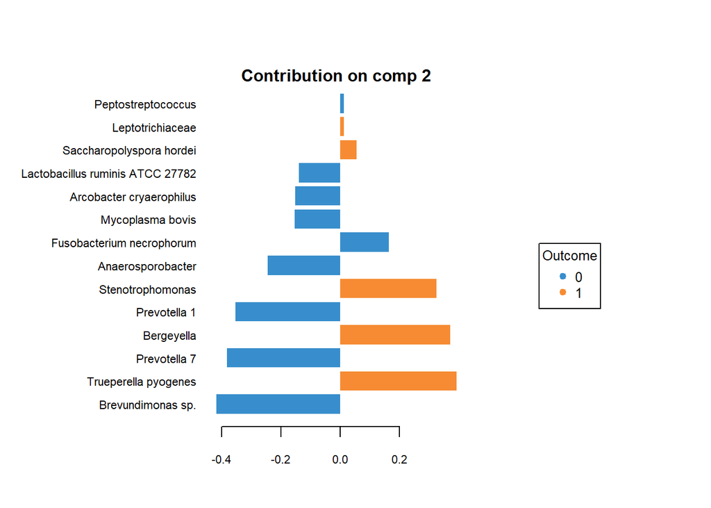

```r
plotLoadings(res_splsda, comp = 2, method = 'mean', contrib = 'max',
             size.title = 1)
```

## PLS-DA on `P.multocida`

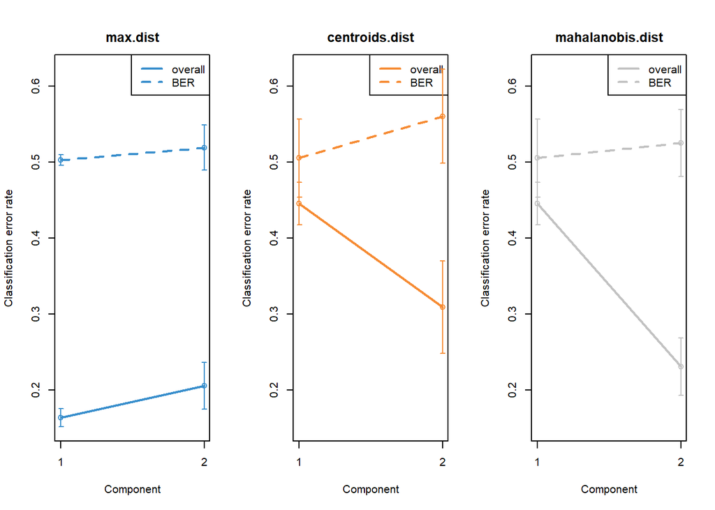

```r
set.seed(11)
res_plsda <- plsda(X=clean_log,Y=Y$Ct.P.multocida, ncomp = nlevels(clean_condition))
res_perf <- perf(res_plsda, validation = 'Mfold', folds = 5,
                 progressBar = FALSE, nrepeat = 20)
plot(res_perf, overlay = 'measure', sd = TRUE)
```

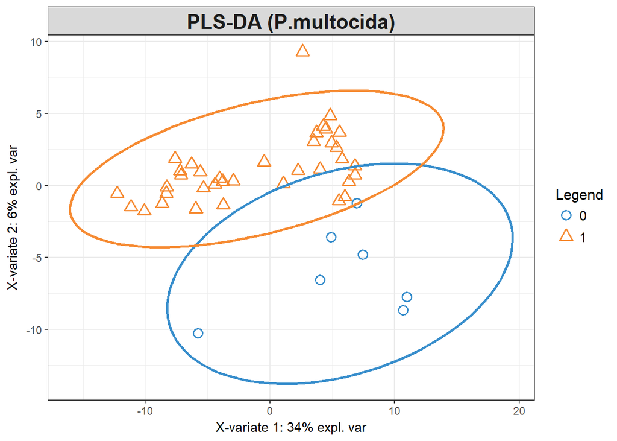

```r
plotIndiv(res_plsda , comp = c(1, 2), ind.names = FALSE, ellipse = TRUE,
          legend = TRUE, title = 'PLS-DA (P.multocida)')
```

```r
set.seed(33)
res_plsda <- tune.splsda(X=clean_log,Y=Y$Ct.P.multocida,
                         ncomp = nlevels(clean_condition),
                         multilevel = clean_id,
                         test.keepX = 1:20, validation = 'Mfold',
                         folds = 10, dist = 'mahalanobis.dist', nrepeat = 10,
                         progressBar = F)
```

```
## Splitting the variation for 1 level factor.
```

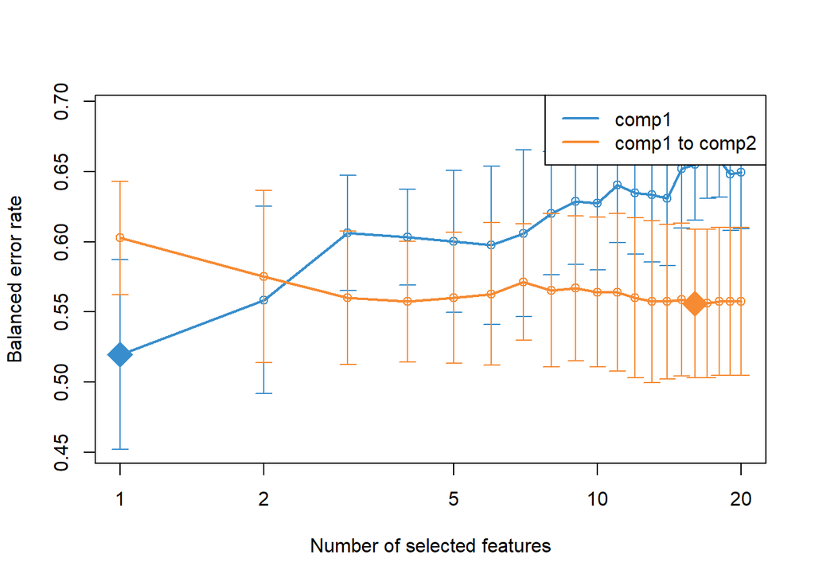

```r
plot(res_plsda)
```

```r
sel_keepX <- res_plsda$choice.keepX[1:2]
sel_keepX
```

```
## comp1 comp2
##     1    16
```

```r
res_splsda <- splsda(X=clean_log,Y=Y$Ct.P.multocida,
                     ncomp = nlevels(clean_condition),
                     multilevel = clean_id,
                     keepX = sel_keepX)
```

```
## Splitting the variation for 1 level factor.
```

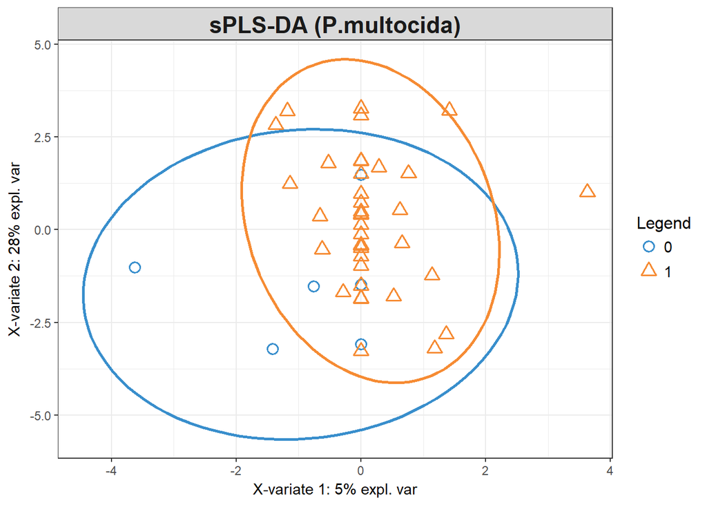

```r
plotIndiv(res_splsda, comp = c(1,2), ind.names = FALSE, ellipse = TRUE,
          legend = TRUE, title = 'sPLS-DA (P.multocida)')
```

```r
head(selectVar(res_splsda, comp = 1)$name)
```

```
## [1] "Saccharomonospora glauca K62"
```

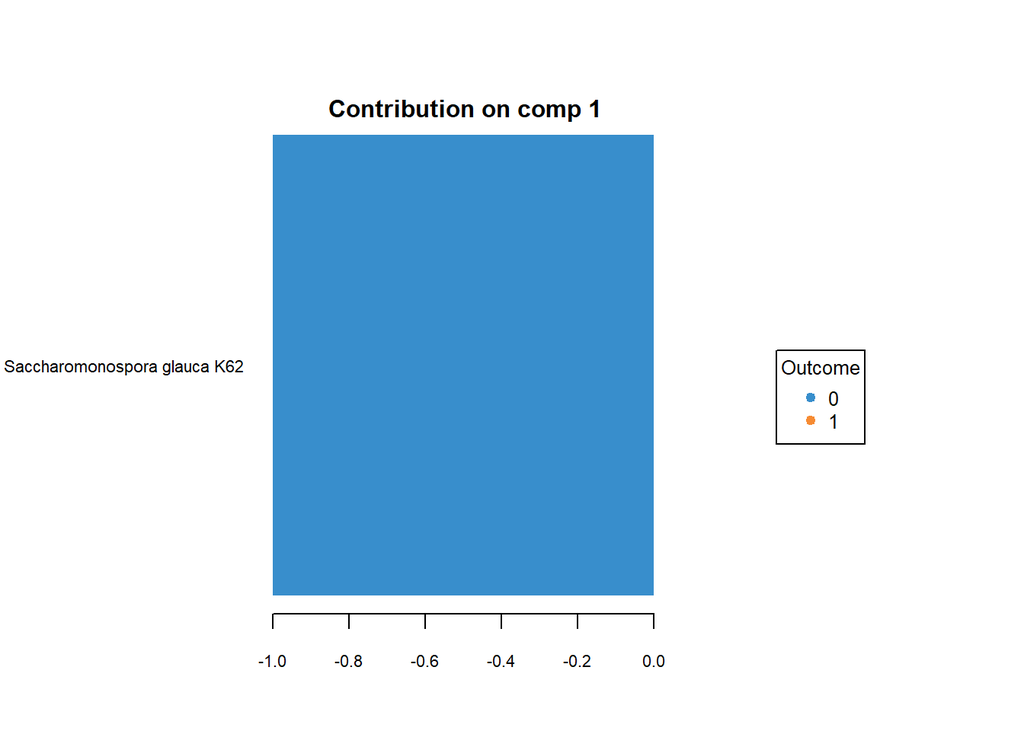

```r
plotLoadings(res_splsda, comp = 1, method = 'mean', contrib = 'max',
             size.title = 1)
```

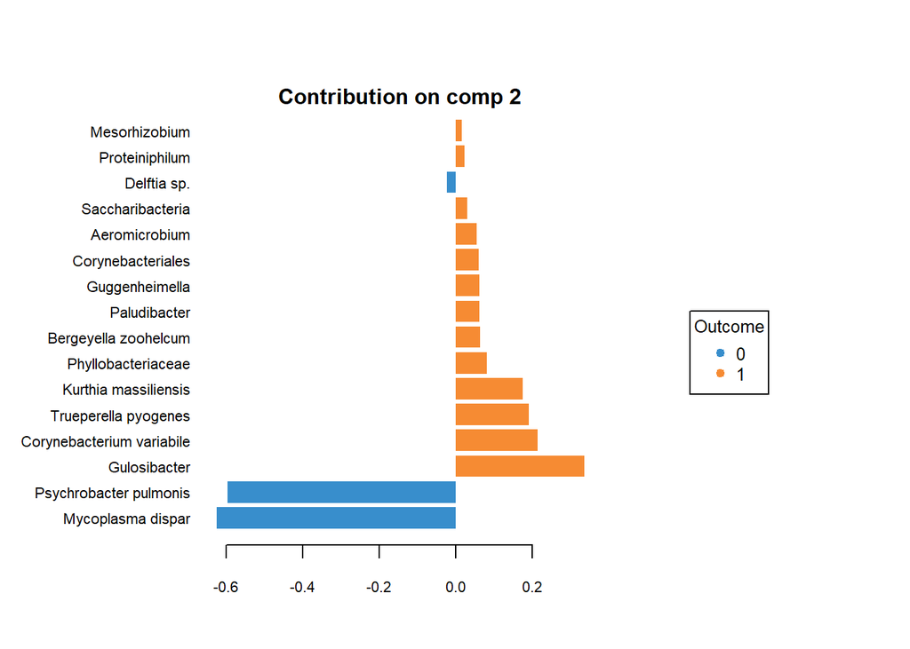

```r
plotLoadings(res_splsda, comp = 2, method = 'mean', contrib = 'max',
             size.title = 1)
```

## PLS-DA on `M.haemolytica`

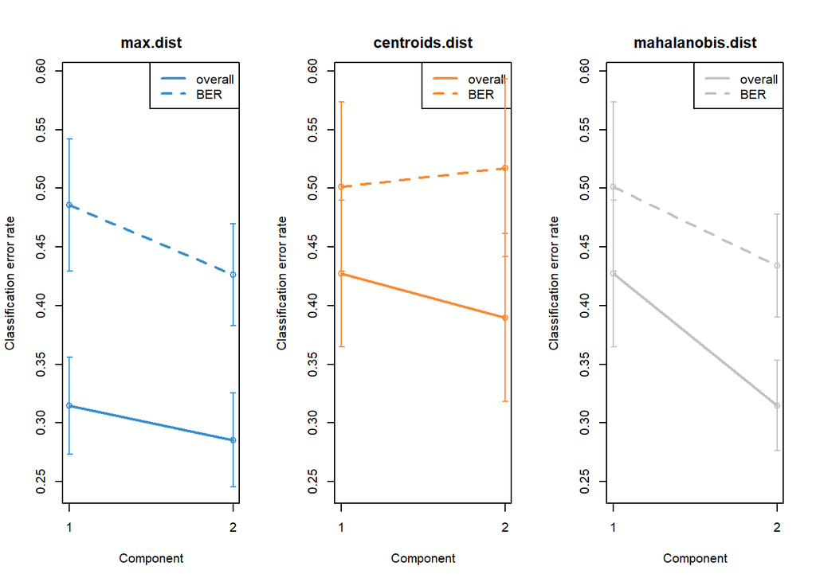

```r
set.seed(11)
res_plsda <- plsda(X=clean_log,Y=Y$Ct.M.haemolytica, ncomp = nlevels(clean_condition))
res_perf <- perf(res_plsda, validation = 'Mfold', folds = 5,
                 progressBar = FALSE, nrepeat = 20)
plot(res_perf, overlay = 'measure', sd = TRUE)
```

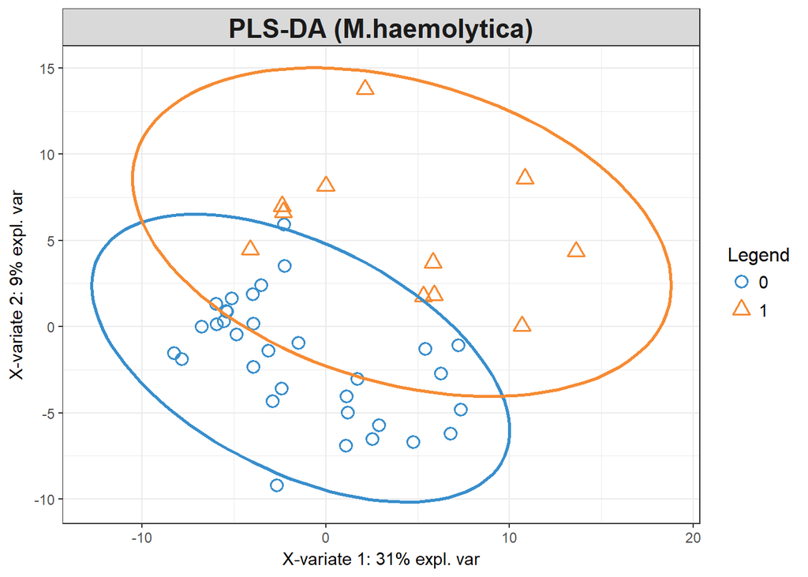

```r
plotIndiv(res_plsda , comp = c(1, 2), ind.names = FALSE, ellipse = TRUE,
          legend = TRUE, title = 'PLS-DA (M.haemolytica)')
```

```r
set.seed(33)
res_plsda <- tune.splsda(X=clean_log,Y=Y$Ct.M.haemolytica,
                         ncomp = nlevels(clean_condition),
                         multilevel = clean_id,
                         test.keepX = 1:20, validation = 'Mfold',
                         folds = 10, dist = 'mahalanobis.dist', nrepeat = 10,
                         progressBar = F)
```

```
## Splitting the variation for 1 level factor.
```

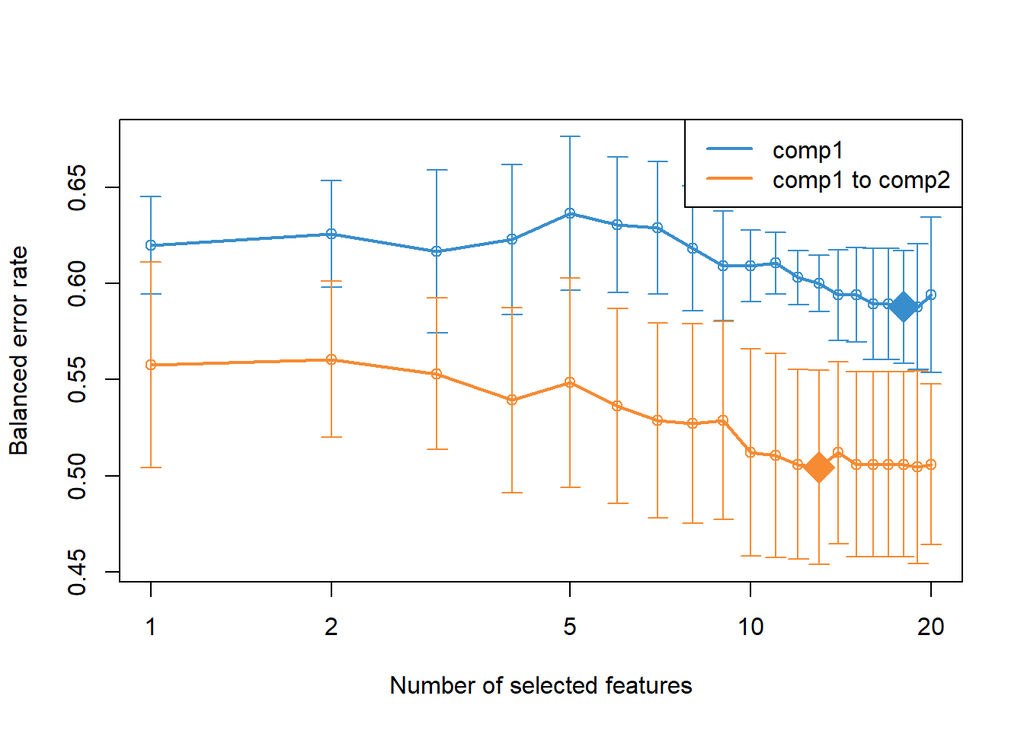

```r
plot(res_plsda)
```

```r
sel_keepX <- res_plsda$choice.keepX[1:2]
sel_keepX
```

```
## comp1 comp2
##    18    13
```

```r
res_splsda <- splsda(X=clean_log,Y=Y$Ct.M.haemolytica,
                     ncomp = nlevels(clean_condition),
                     multilevel = clean_id,
                     keepX = sel_keepX)
```

```
## Splitting the variation for 1 level factor.
```

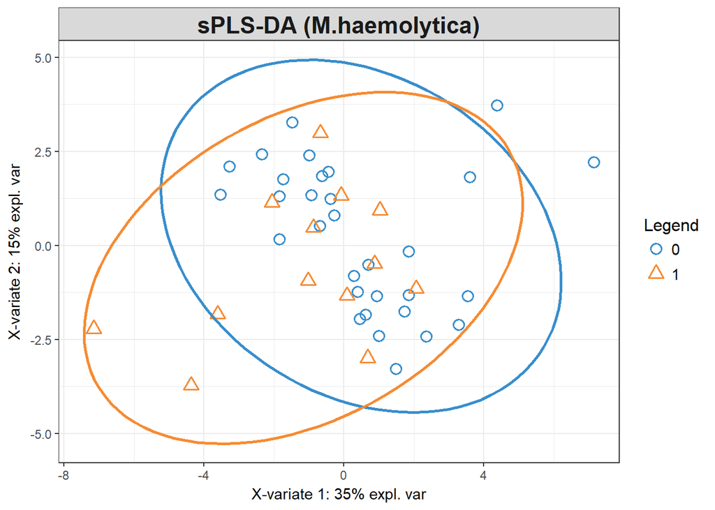

```r
plotIndiv(res_splsda, comp = c(1,2), ind.names = FALSE, ellipse = TRUE,
          legend = TRUE, title = 'sPLS-DA (M.haemolytica)')
```

```r
head(selectVar(res_splsda, comp = 1)$name)
```

```
## [1] "Eubacterium rectale"             "Propionibacteriaceae"
## [3] "Bacteroidales S24-7 group"       "Bacillus sp."
## [5] "[Ruminococcus] gauvreauii group" "Prevotellaceae"
```

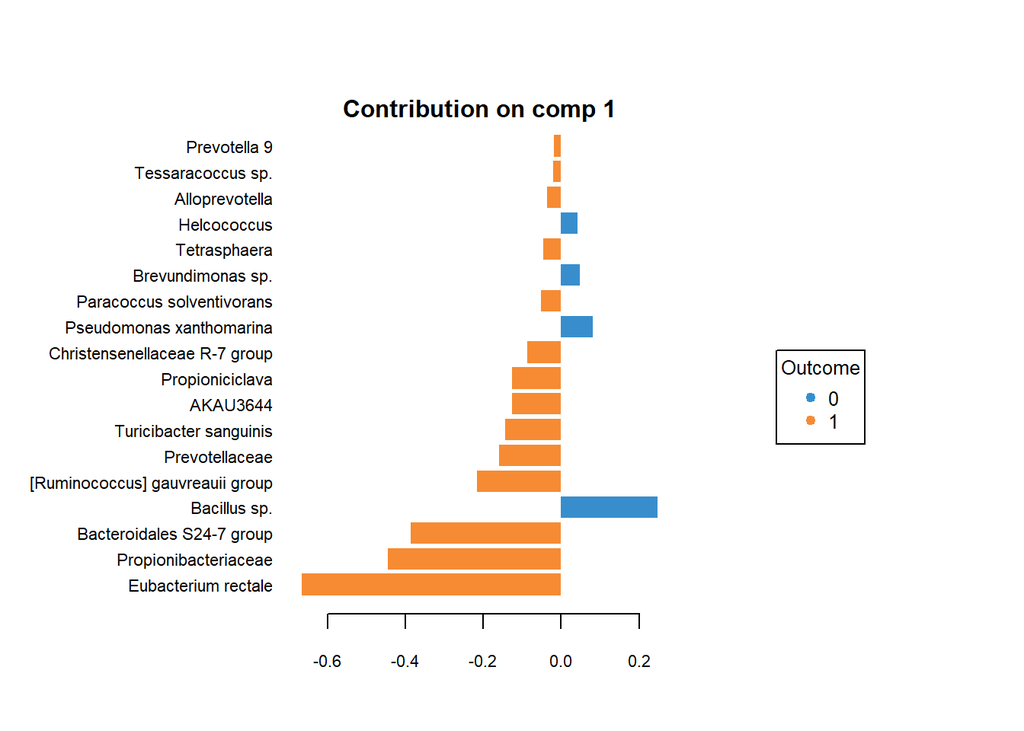

```r
plotLoadings(res_splsda, comp = 1, method = 'mean', contrib = 'max',
             size.title = 1)
```

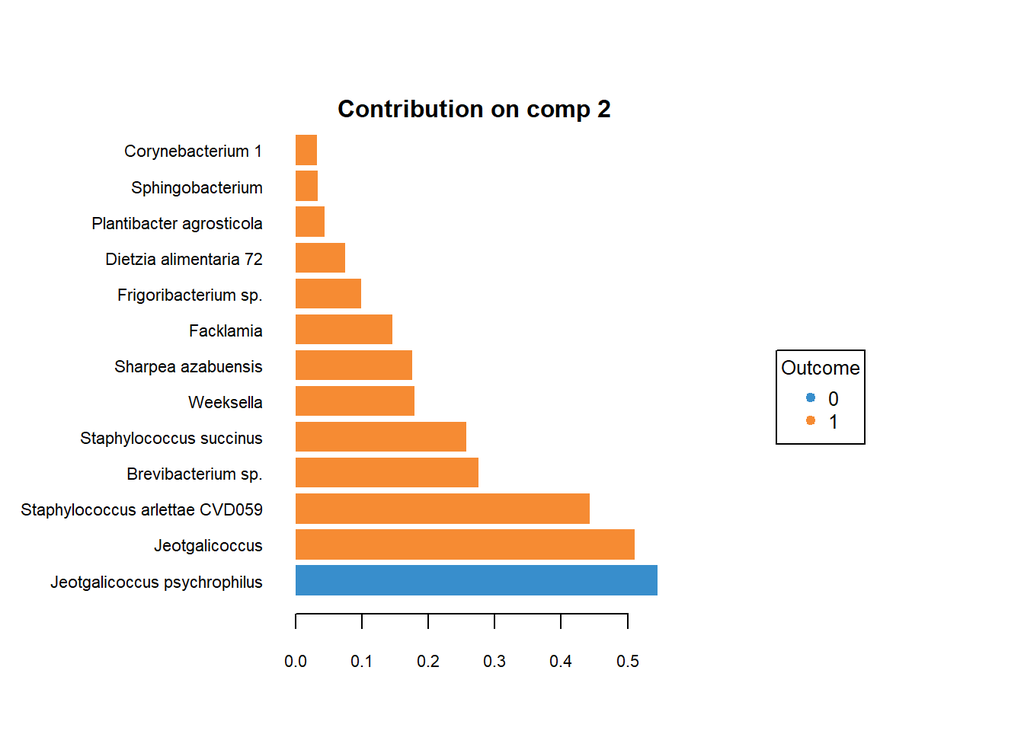

```r
plotLoadings(res_splsda, comp = 2, method = 'mean', contrib = 'max',
             size.title = 1)
```

## PLS-DA on `M.bovis`

```r
set.seed(11)
res_plsda <- plsda(X=clean_log,Y=Y$Ct.M.bovis, ncomp = nlevels(clean_condition))
res_perf <- perf(res_plsda, validation = 'Mfold', folds = 5,
                 progressBar = FALSE, nrepeat = 20)
```

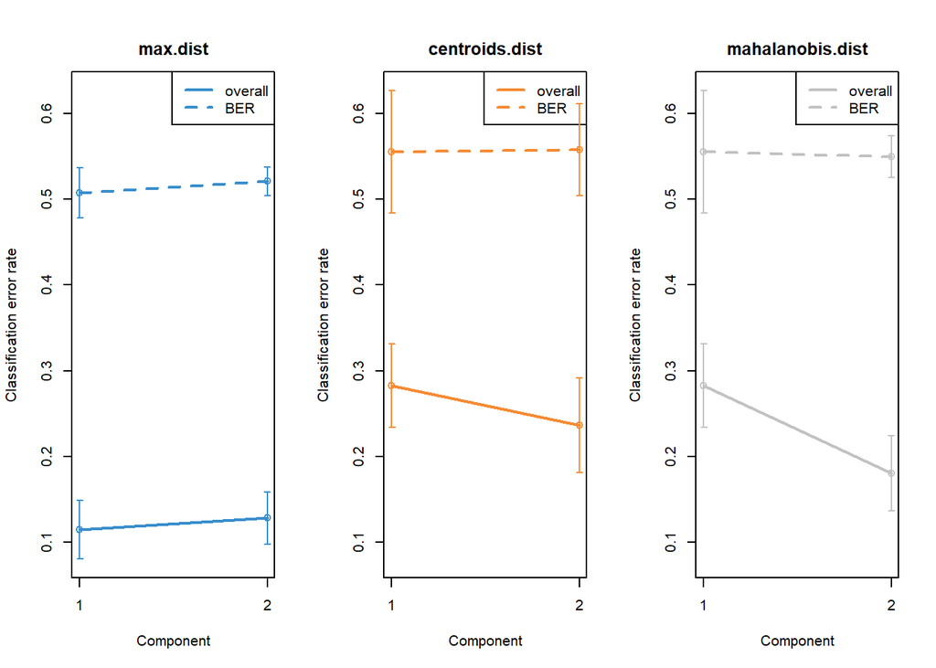

```r
plot(res_perf, overlay = 'measure', sd = TRUE)
```

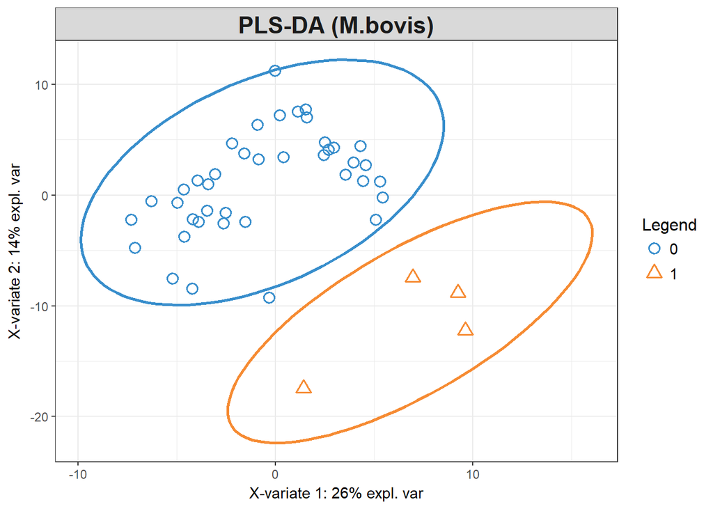

```r
plotIndiv(res_plsda , comp = c(1, 2), ind.names = FALSE, ellipse = TRUE,
          legend = TRUE, title = 'PLS-DA (M.bovis)')
```

```r
set.seed(33)
res_plsda <- tune.splsda(X=clean_log,Y=Y$Ct.M.bovis,
                         ncomp = nlevels(clean_condition),
                         multilevel = clean_id,
                         test.keepX = 1:20, validation = 'Mfold',
                         folds = 10, dist = 'mahalanobis.dist', nrepeat = 10,
                         progressBar = F)
```

```
## Splitting the variation for 1 level factor.
```

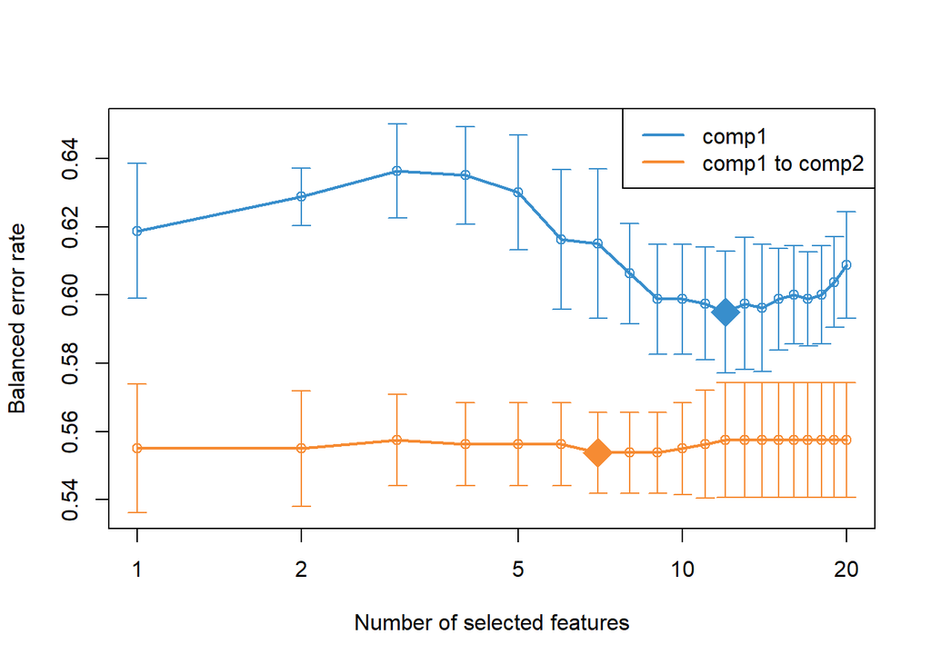

```r
plot(res_plsda)
```

```r
sel_keepX <- res_plsda$choice.keepX[1:2]
sel_keepX
```

```
## comp1 comp2
##    12     7
```

```r
res_splsda <- splsda(X=clean_log,Y=Y$Ct.M.bovis,
                     ncomp = nlevels(clean_condition),
                     multilevel = clean_id,
                     keepX = sel_keepX)
```

```
## Splitting the variation for 1 level factor.
```

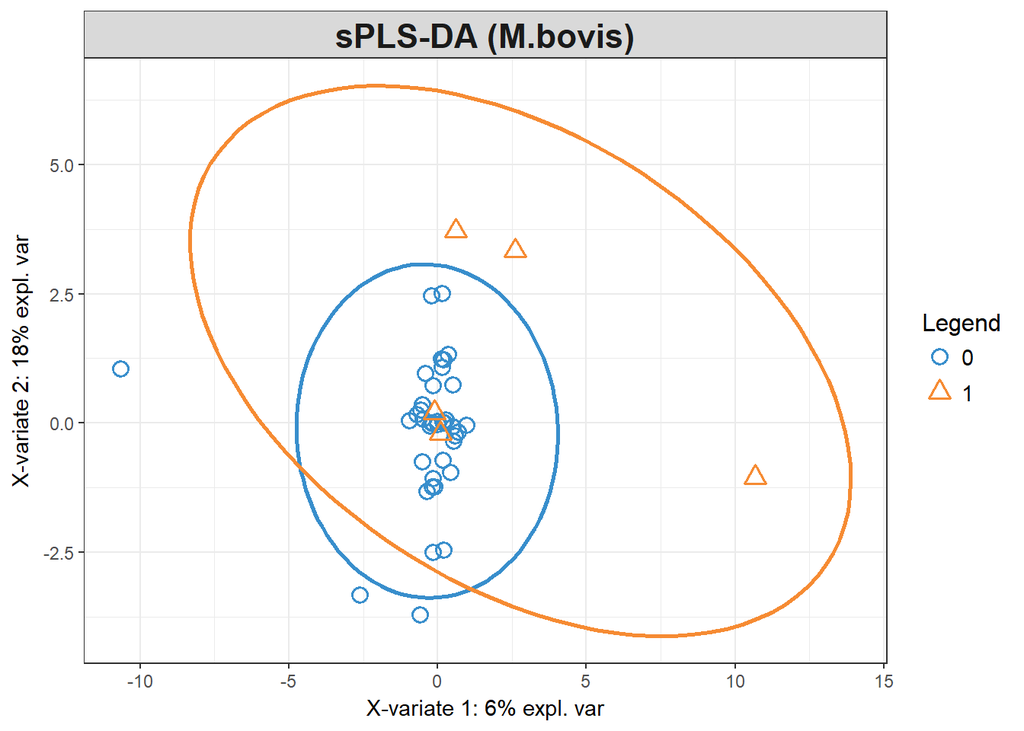

```r
plotIndiv(res_splsda, comp = c(1,2), ind.names = FALSE, ellipse = TRUE,
          legend = TRUE, title = 'sPLS-DA (M.bovis)')
```

```r
head(selectVar(res_splsda, comp = 1)$name)
```

```
## [1] "Mycoplasma bovis"                "Eubacteriaceae bacterium BL-152"
## [3] "Atopobium fossor"                "Filifactor alocis ATCC 35896"
## [5] "Bacteroides pyogenes"            "Bergeyella"
```

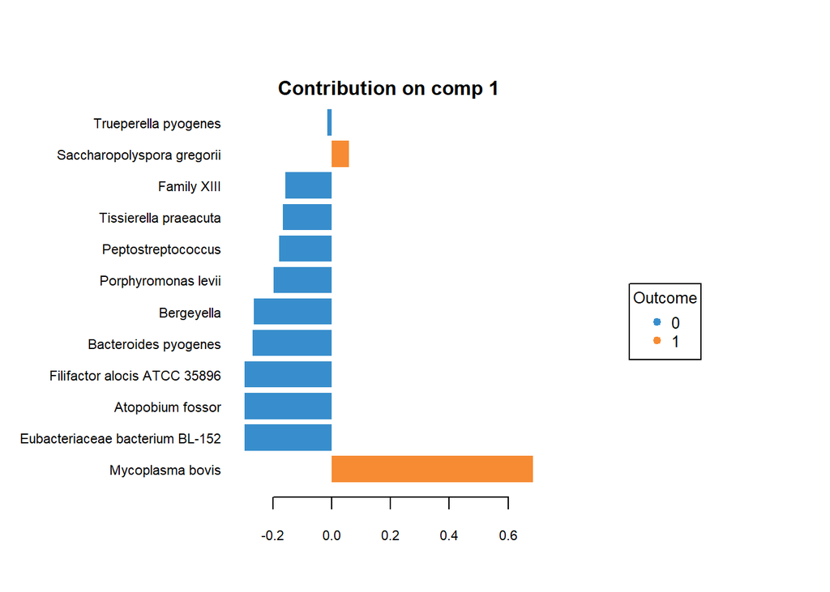

```r
plotLoadings(res_splsda, comp = 1, method = 'mean', contrib = 'max',
             size.title = 1)
```

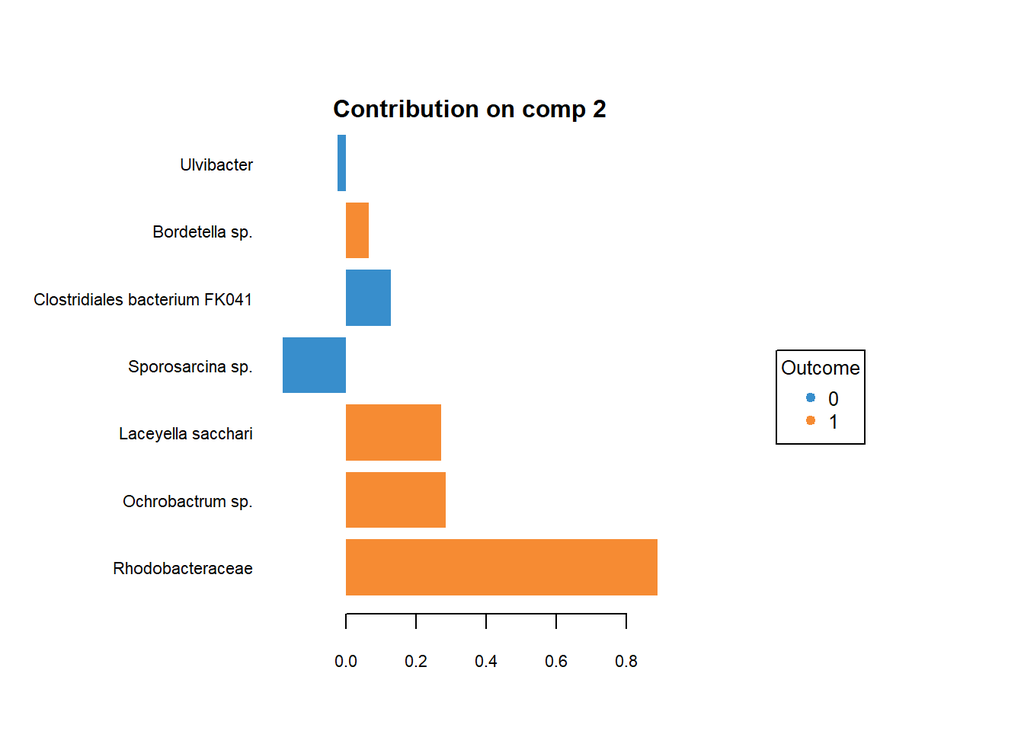

```r
plotLoadings(res_splsda, comp = 2, method = 'mean', contrib = 'max',
             size.title = 1)
```

## PLS-DA on `H.somni`

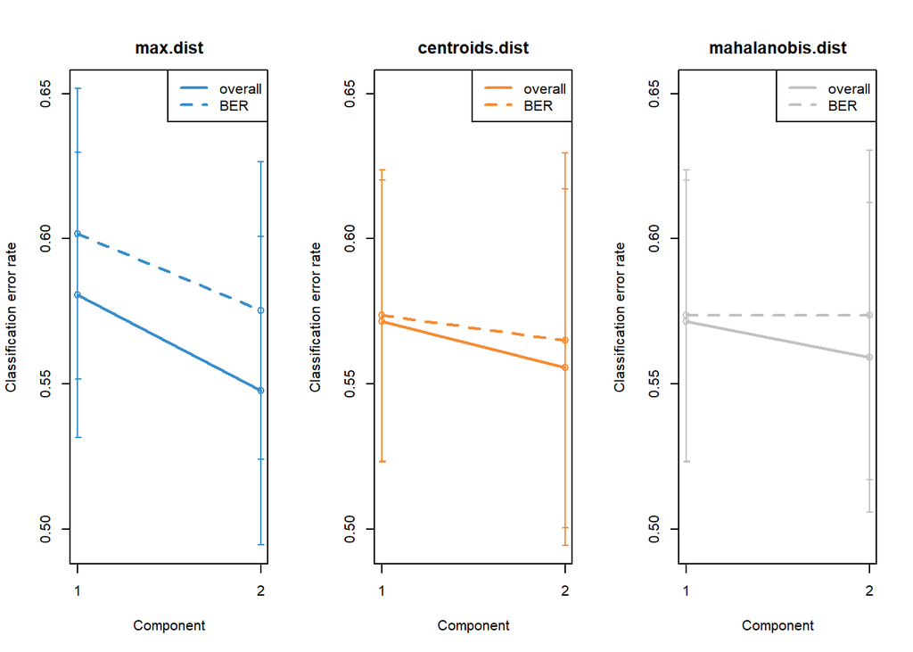

```r
set.seed(11)
res_plsda <- plsda(X=clean_log,Y=Y$Ct.H.somni, ncomp = nlevels(clean_condition))
res_perf <- perf(res_plsda, validation = 'Mfold', folds = 5,
                 progressBar = FALSE, nrepeat = 20)
plot(res_perf, overlay = 'measure', sd = TRUE)
```

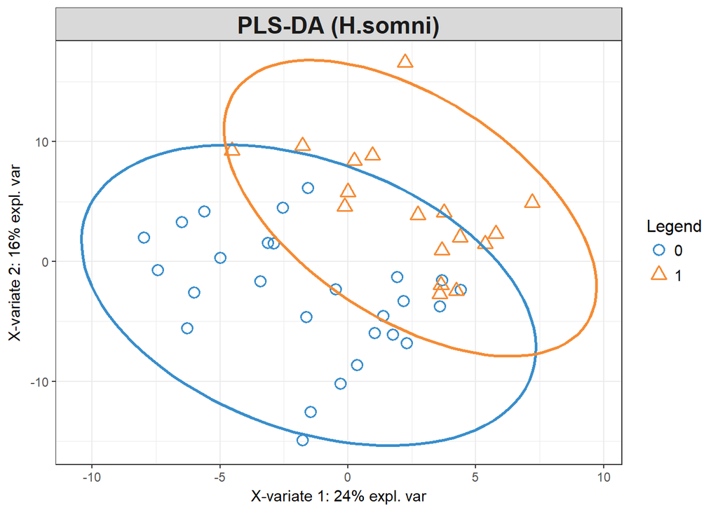

```r
plotIndiv(res_plsda , comp = c(1, 2), ind.names = FALSE, ellipse = TRUE,
          legend = TRUE, title = 'PLS-DA (H.somni)')
```

```r
set.seed(33)
res_plsda <- tune.splsda(X=clean_log,Y=Y$Ct.H.somni,
                         ncomp = nlevels(clean_condition),
                         multilevel = clean_id,
                         test.keepX = 1:20, validation = 'Mfold',
                         folds = 10, dist = 'mahalanobis.dist', nrepeat = 10,
                         progressBar = F)
```

```
## Splitting the variation for 1 level factor.
```

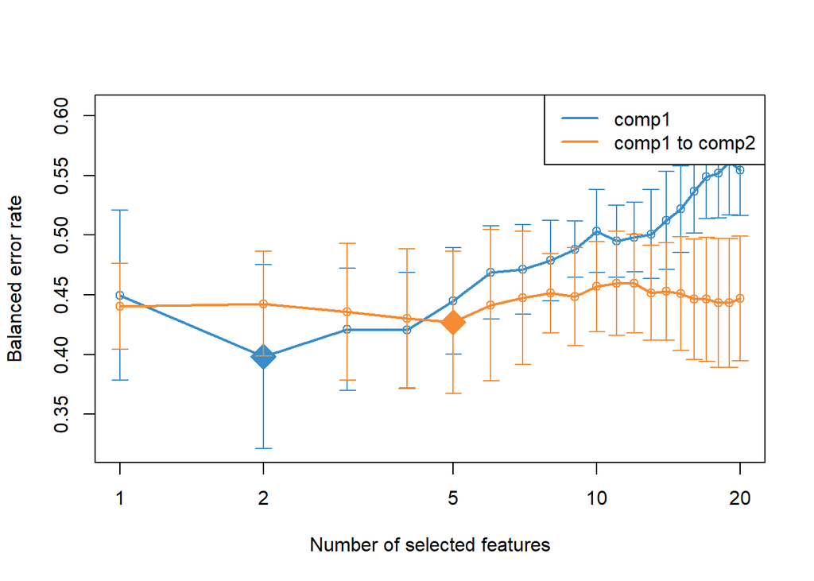

```r
plot(res_plsda)
```

```r
sel_keepX <- res_plsda$choice.keepX[1:2]
sel_keepX
```

```
## comp1 comp2
##     2     5
```

```r
res_splsda <- splsda(X=clean_log,Y=Y$Ct.H.somni,
                     ncomp = nlevels(clean_condition),
                     multilevel = clean_id,
                     keepX = sel_keepX)
```

```
## Splitting the variation for 1 level factor.
```

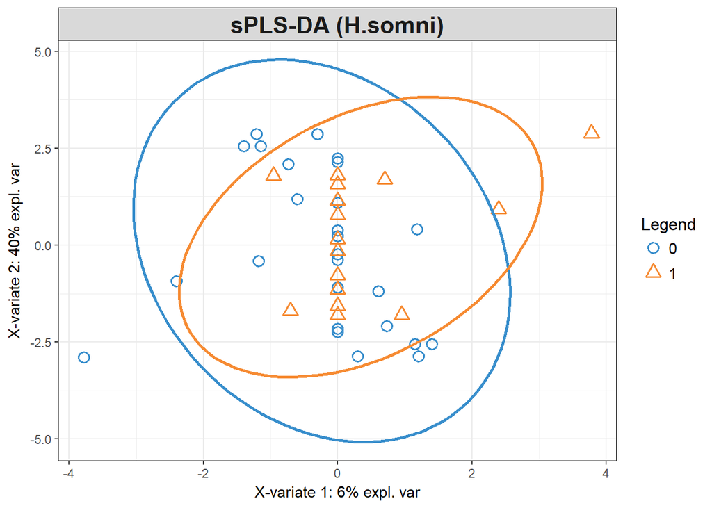

```r
plotIndiv(res_splsda, comp = c(1,2), ind.names = FALSE, ellipse = TRUE,
          legend = TRUE, title = 'sPLS-DA (H.somni)')
```

```r
head(selectVar(res_splsda, comp = 1)$name)
```

```
## [1] "Streptococcus"                  "Actinoalloteichus cyanogriseus"
```

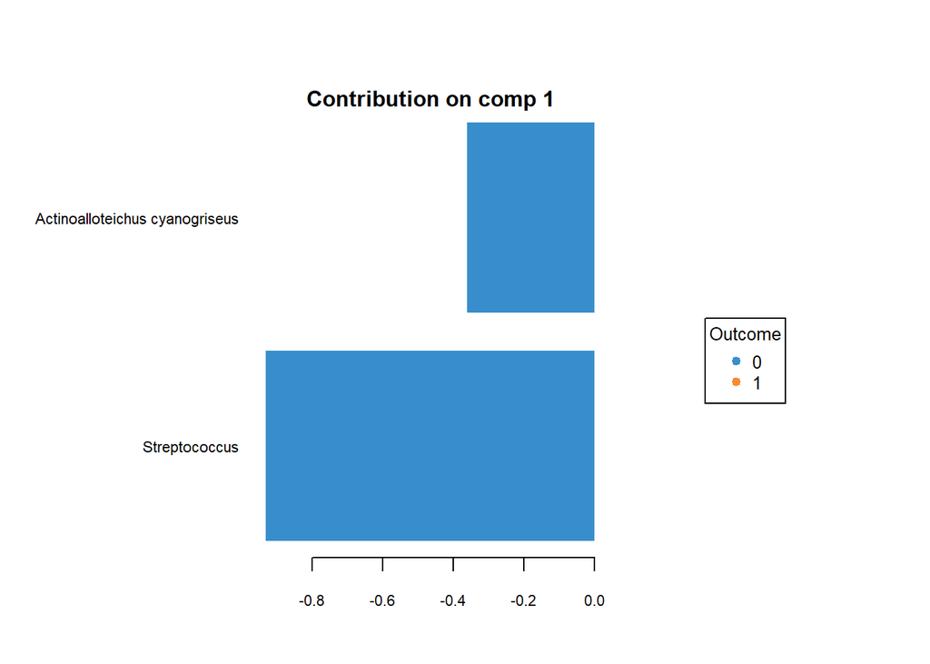

```r
plotLoadings(res_splsda, comp = 1, method = 'mean', contrib = 'max',
             size.title = 1)
```

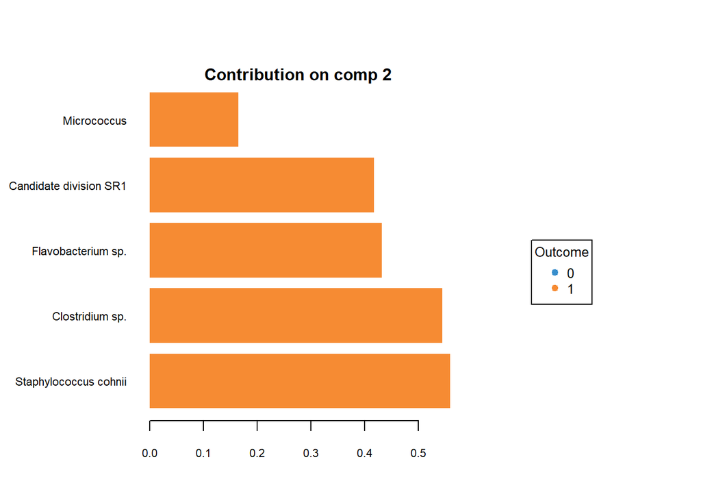

```r
plotLoadings(res_splsda, comp = 2, method = 'mean', contrib = 'max',
             size.title = 1)
```

# sPLS with regression mode - `EN` condition

```r
pls <- pls(as.matrix(sapply(clean_log_EN,as.numeric)), as.matrix(sapply(Y_EN,as.numeric)), ncomp = 2, mode = "regression")
spls <- spls(as.matrix(sapply(clean_log_EN,as.numeric)), as.matrix(sapply(Y_EN,as.numeric)), ncomp =2,
             keepX= c(15,15), keepY=c(7,7), mode = "regression")
tune.pls <- perf(pls, validation = "Mfold", folds = 20,
                 progressBar = FALSE, nrepeat = 10)
tune.spls <- perf(spls, validation = "Mfold", folds = 20,
                  progressBar = FALSE, nrepeat = 10)
tune.pls$Q2.total
```

```
##           Q2.total
## 1 comp -0.05644524
## 2 comp -0.10451848
```

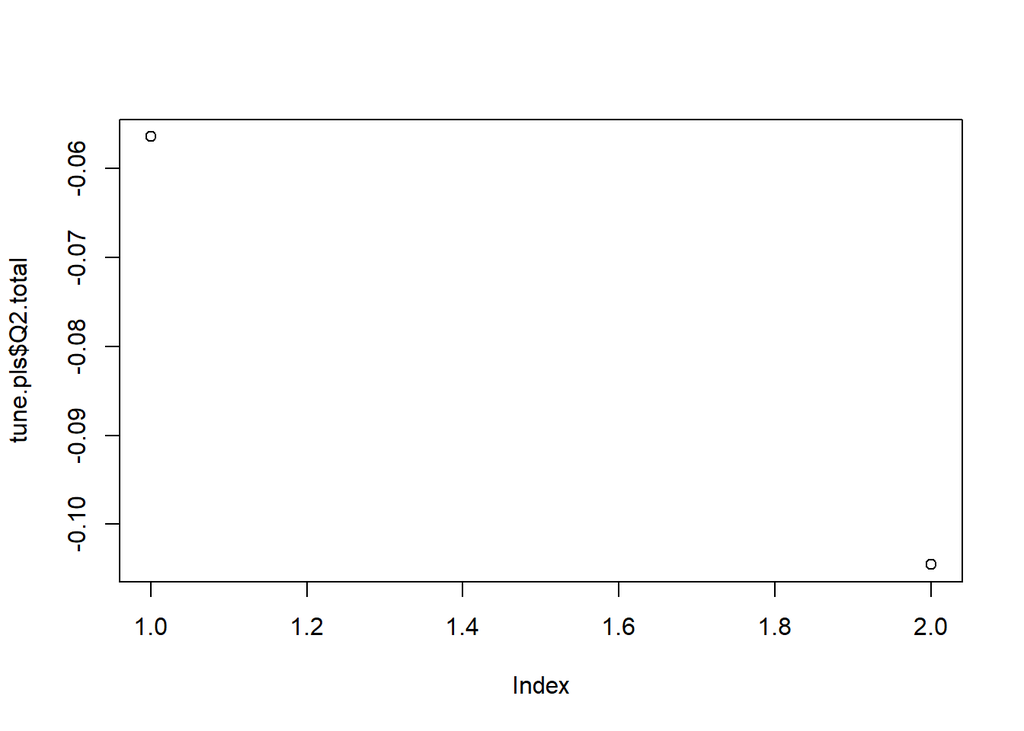

```r
plot(tune.pls$Q2.total)
abline(h=0.0975)
```

## Sample Plots

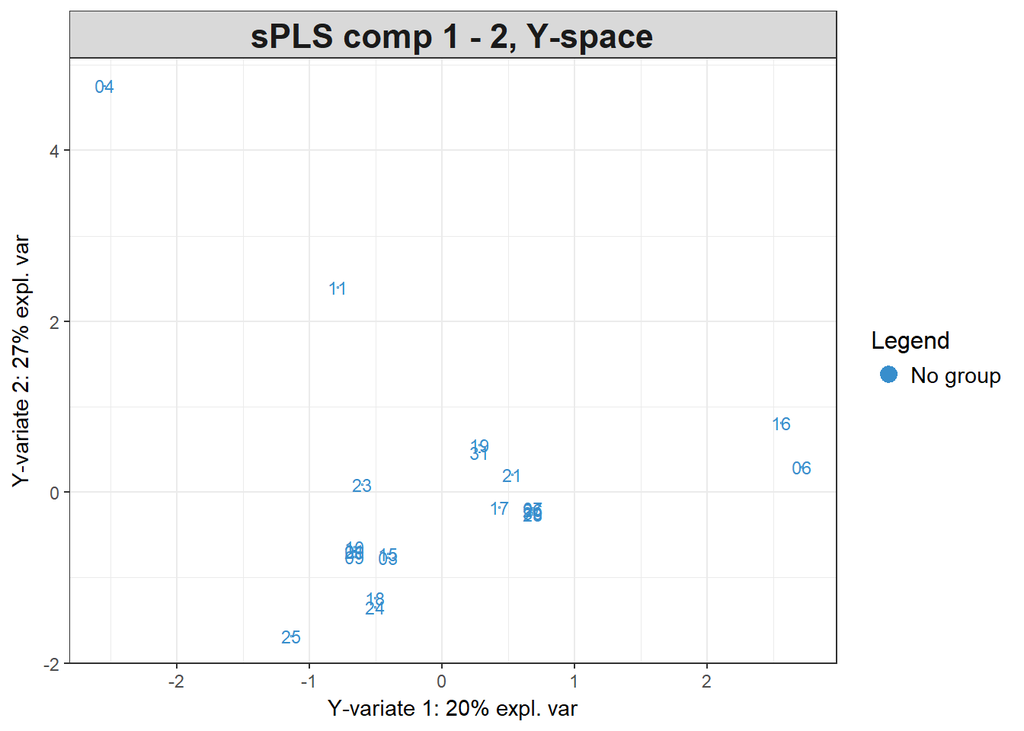

```r
plotIndiv(spls, comp = 1:2, rep.space= 'Y-variate', ind.names = clean_id[grep("EN",names(clean_id))],
legend = TRUE, title = 'sPLS comp 1 - 2, Y-space')
```

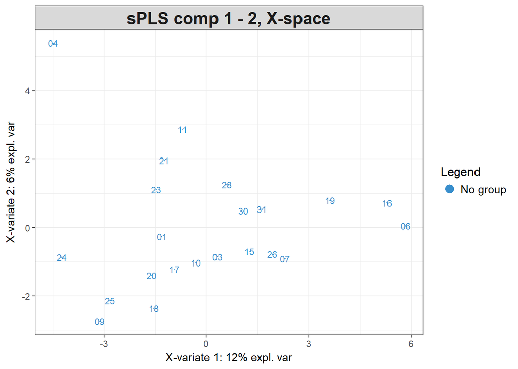

```r
plotIndiv(spls, comp = 1:2, rep.space= 'X-variate', ind.names = clean_id[grep("EN",names(clean_id))],
legend = TRUE, title = 'sPLS comp 1 - 2, X-space')
```

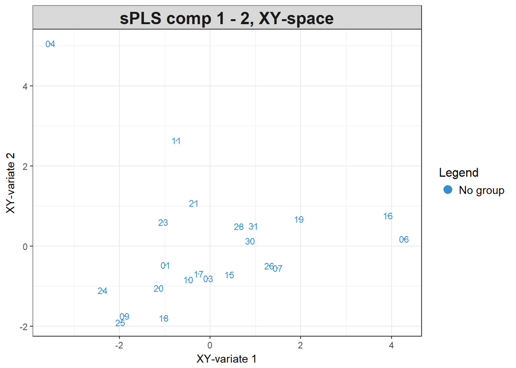

```r
plotIndiv(spls, comp = 1:2, rep.space= 'XY-variate', ind.names = clean_id[grep("EN",names(clean_id))],
legend = TRUE, title = 'sPLS comp 1 - 2, XY-space')
```

Individual plots can be displayed on three different subspaces spanned either by the X variable, the Y variable or the mean subspace in which coordinates are averaged from the first two subspaces (XY).

## Variable Plot

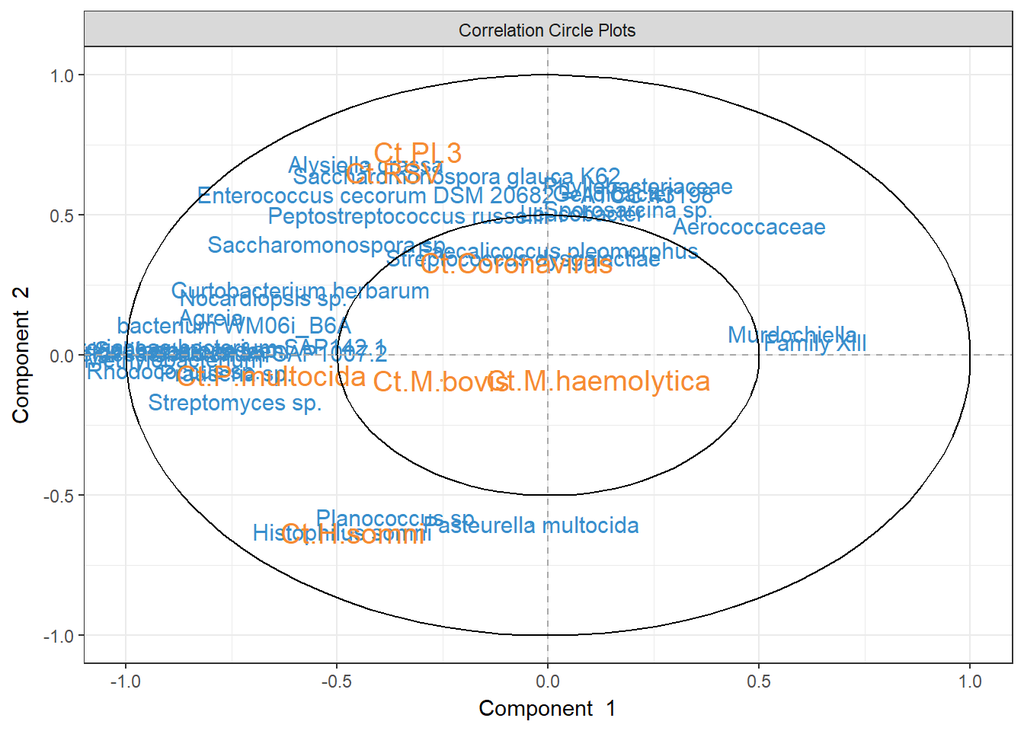

```r
plotVar(spls, comp =1:2, var.names = list(X.label = species,
        Y.label = TRUE), cex = c(4, 5))
```

# sPLS with regression mode - `LBA` condition

```r
pls <- pls(as.matrix(sapply(clean_log_LBA,as.numeric)), as.matrix(sapply(Y_LBA,as.numeric)), ncomp = 8, mode = "regression")
spls <- spls(as.matrix(sapply(clean_log_LBA,as.numeric)), as.matrix(sapply(Y_LBA,as.numeric)), ncomp =8,
             keepX= c(15,15), keepY=c(7,7), mode = "regression")
tune.pls <- perf(pls, validation = "Mfold", folds = 20,
                 progressBar = FALSE, nrepeat = 10)
tune.spls <- perf(spls, validation = "Mfold", folds = 20,
                  progressBar = FALSE, nrepeat = 10)
tune.pls$Q2.total
```

```
##            Q2.total
## 1 comp -0.021153712
## 2 comp -0.013099148
## 3 comp -0.018266768
## 4 comp -0.003367460
## 5 comp  0.020938526
## 6 comp -0.053575966
## 7 comp  0.103777737
## 8 comp  0.009090455
```

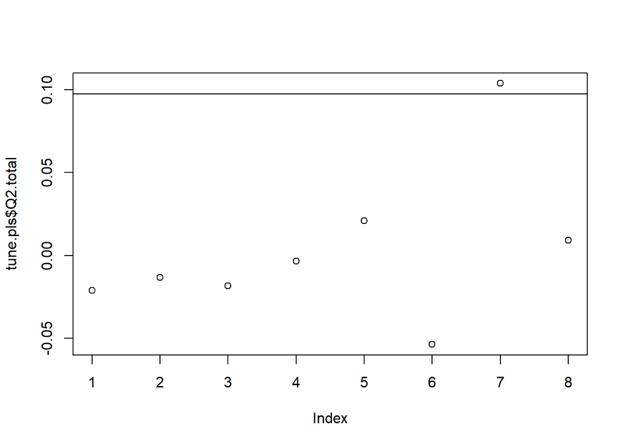

```r
plot(tune.pls$Q2.total)
abline(h=0.0975)
```

## Sample Plots

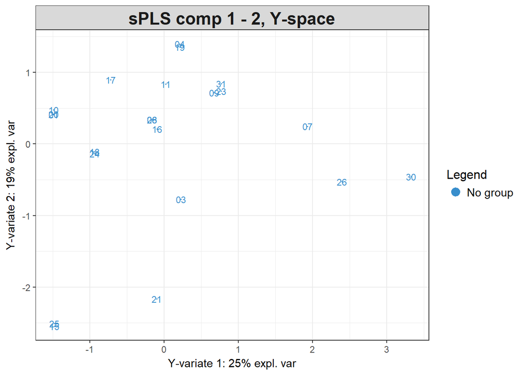

```r
plotIndiv(spls, comp = 1:2, rep.space= 'Y-variate', ind.names = clean_id_LBA,
legend = TRUE, title = 'sPLS comp 1 - 2, Y-space')
```

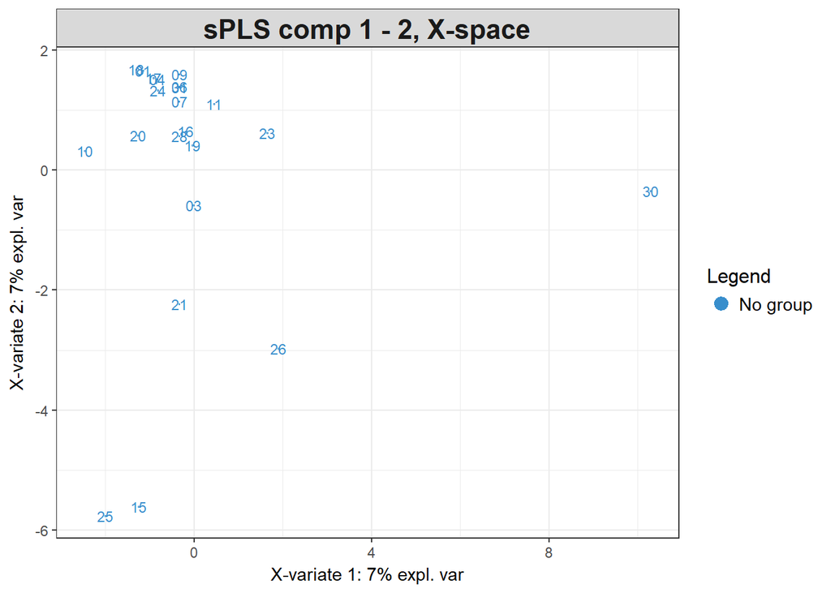

```r
plotIndiv(spls, comp = 1:2, rep.space= 'X-variate', ind.names = clean_id_LBA,
legend = TRUE, title = 'sPLS comp 1 - 2, X-space')
```

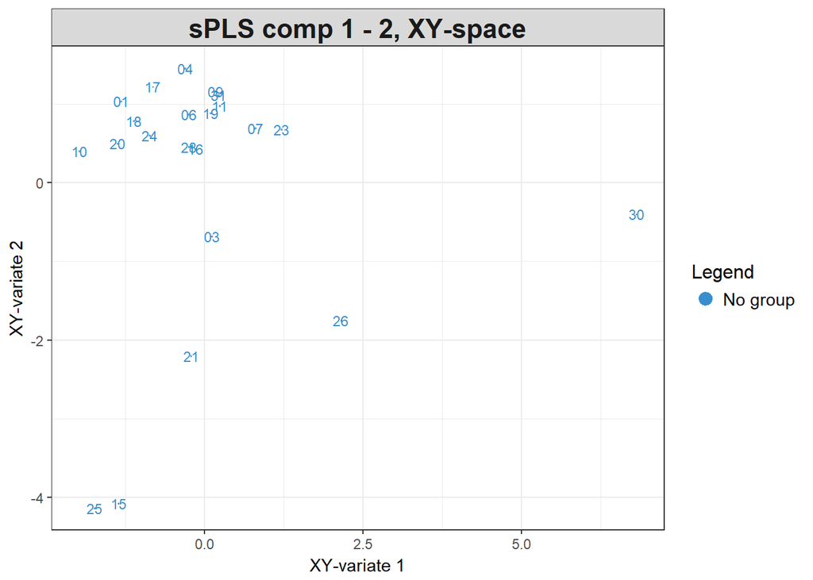

```r
plotIndiv(spls, comp = 1:2, rep.space= 'XY-variate', ind.names = clean_id_LBA,
legend = TRUE, title = 'sPLS comp 1 - 2, XY-space')
```

Individual plots can be displayed on three different subspaces spanned either by the X variable, the Y variable or the mean subspace in which coordinates are averaged from the first two subspaces (XY).

## Variable Plot

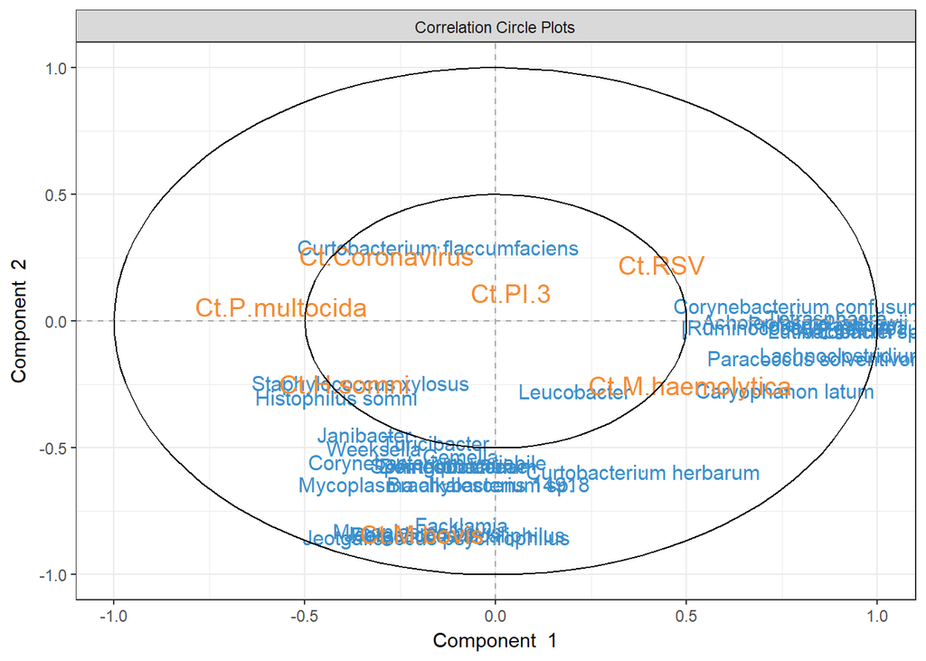

```r
plotVar(spls, comp =1:2, var.names = list(X.label = species,
        Y.label = TRUE), cex = c(4, 5))
```

```r
#cim(spls, comp = 1:2, xlab = "virus", ylab = "genes")
```

# Work on one condition

Regroupment of `RSV`, `PI.3`, `Coronavirus`

```r
group_virus<-sapply(Y,as.numeric)
group_virus<-group_virus-1
group_virus<-group_virus[,1]+group_virus[,2]+group_virus[,3]
group_virus[group_virus>0]<-1
group_virus <- as.factor(group_virus)

group_virus_EN <- group_virus[grep("EN",rownames(Y))]
group_virus_LBA <- group_virus[grep("LBA",rownames(Y))]
```

## PLS-DA on `group_virus` - `EN` condition

```r
set.seed(11)
res_plsda <- plsda(X=clean_log_EN,Y=group_virus_EN, ncomp = nlevels(group_virus_EN))
```

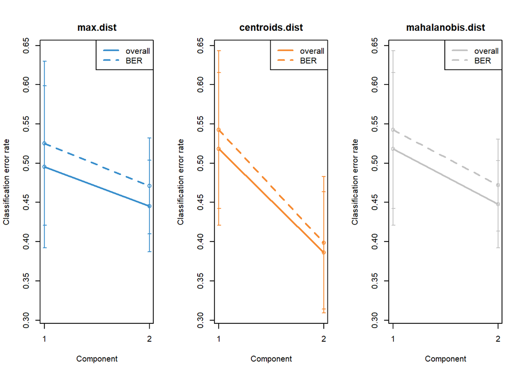

```r
res_perf <- perf(res_plsda, validation = 'Mfold', folds = 5,
                 progressBar = FALSE, nrepeat = 20)
plot(res_perf, overlay = 'measure', sd = TRUE)
```

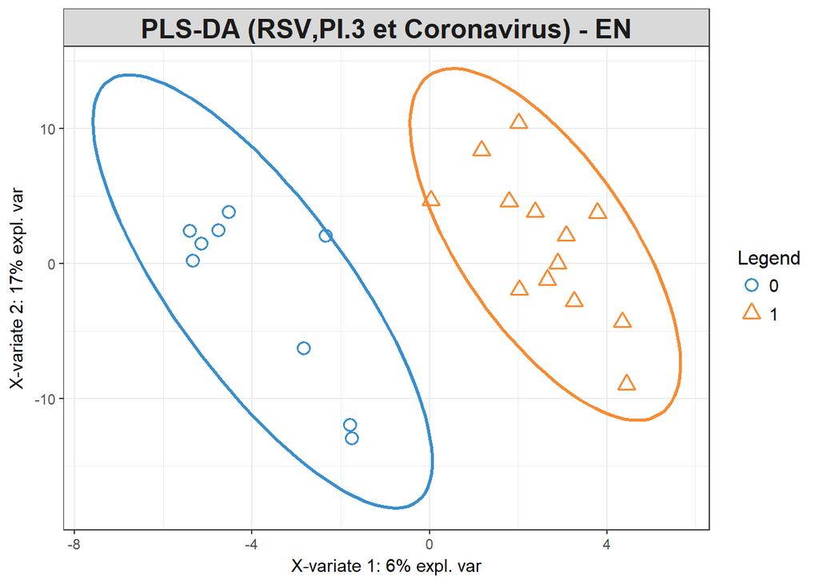

```r
plotIndiv(res_plsda , comp = c(1, 2), ind.names = FALSE, ellipse = TRUE,
          legend = TRUE, title = 'PLS-DA (RSV,PI.3 et Coronavirus) - EN')
```

```r
set.seed(33)
res_plsda <- tune.splsda(X=clean_log_EN,Y=group_virus_EN,
                         ncomp = nlevels(group_virus_EN),
                         test.keepX = 1:20, validation = 'Mfold',
                         folds = 10, dist = 'mahalanobis.dist', nrepeat = 10,
                         progressBar = F)
```

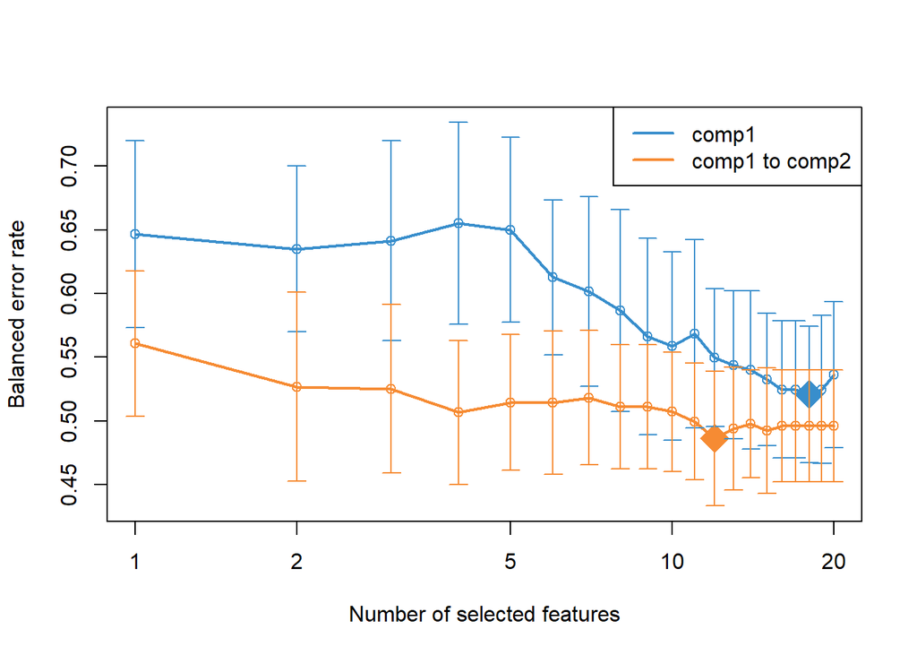

```r
plot(res_plsda)
```

```r
sel_keepX <- res_plsda$choice.keepX[1:2]
sel_keepX
```

```
## comp1 comp2
##    18    12
```

```r
res_splsda <- splsda(X=clean_log_EN,Y=group_virus_EN,
                     ncomp = nlevels(group_virus_EN),
                     keepX = sel_keepX)
```

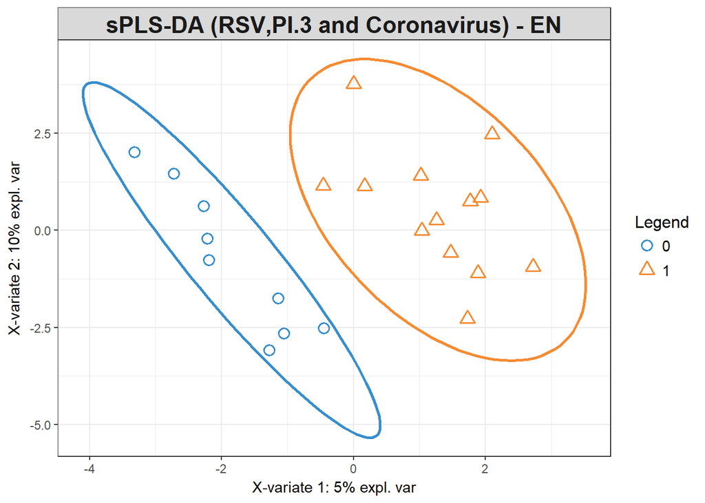

```r
plotIndiv(res_splsda, comp = c(1,2), ind.names = FALSE, ellipse = TRUE,
          legend = TRUE, title = 'sPLS-DA (RSV,PI.3 and Coronavirus) - EN')
```

```r
test <- predict(res_splsda,clean_log_EN)
pred <- test$class$mahalanobis.dist[,2]
get.confusion_matrix(group_virus_EN,predicted=pred)
```

```
##   predicted.as.0 predicted.as.1
## 0              9              0
## 1              0             13
```

```r
head(selectVar(res_splsda, comp = 1)$name)
```

```
## [1] "Leucobacter"                "Corynebacterium confusum"
## [3] "Pseudochrobactrum"          "Gelidibacter"
## [5] "Streptococcus gallolyticus" "Moraxella lacunata"
```

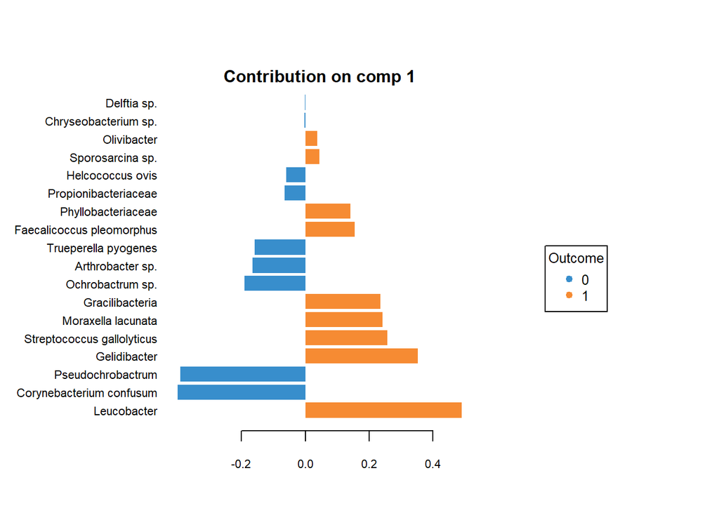

```r
plotLoadings(res_splsda, comp = 1, method = 'mean', contrib = 'max',
             size.title = 1)
```

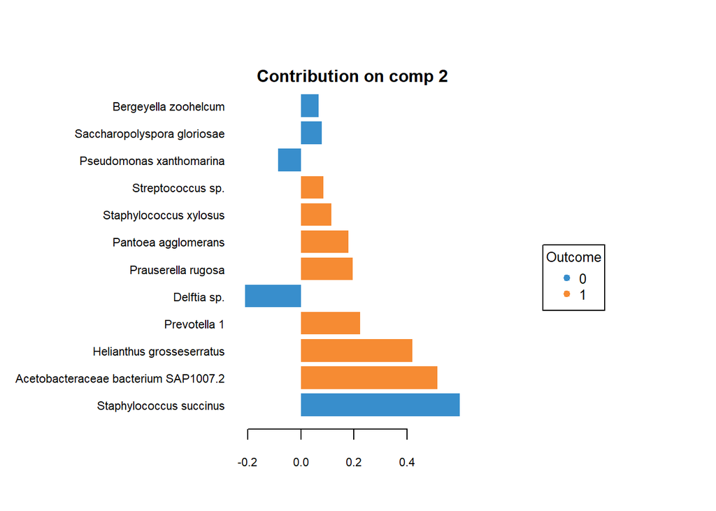

```r
plotLoadings(res_splsda, comp = 2, method = 'mean', contrib = 'max',
             size.title = 1)
```

**Presence vs Absence of viruses: Student tests**

```r
test0 <- clean_log[group_virus_EN=="0",which(selectVar(res_splsda, comp = 1)$name[1]==species)]
test1 <- clean_log[group_virus_EN=="1",which(selectVar(res_splsda, comp = 1)$name[1]==species)]
t.test(test0,test1)
```

```
##
##  Welch Two Sample t-test
##
## data:  test0 and test1
## t = -1.3017, df = 39.609, p-value = 0.2005
## alternative hypothesis: true difference in means is not equal to 0
## 95 percent confidence interval:
##  -1.8458953  0.3998936
## sample estimates:
## mean of x mean of y
##  1.169070  1.892071
```

We do not reject $H_0$ (the difference in means is equal to 0) hence we can say that the presence or not of these three viruses does not change the values of the Leucobacter bateria.

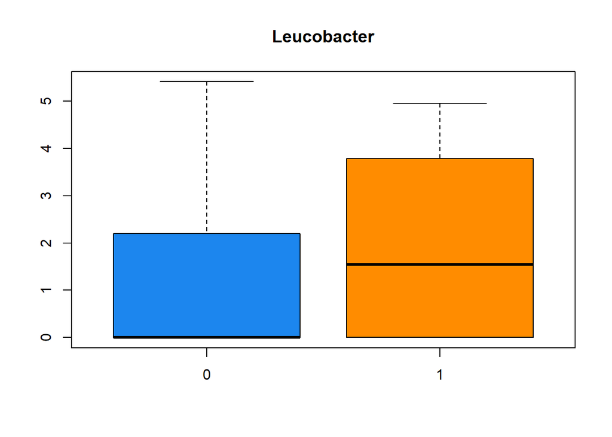

```r
boxplot(test0,test1,names=c("0","1"),
        main=selectVar(res_splsda, comp = 1)$name[1],col=c("dodgerblue2","darkorange"))
```

```r
test0 <- clean_log[group_virus_EN=="0",which(selectVar(res_splsda, comp = 1)$name[2]==species)]
test1 <- clean_log[group_virus_EN=="1",which(selectVar(res_splsda, comp = 1)$name[2]==species)]
t.test(test0,test1)
```

```
##
##  Welch Two Sample t-test
##
## data:  test0 and test1
## t = 2.115, df = 24.322, p-value = 0.04486
## alternative hypothesis: true difference in means is not equal to 0
## 95 percent confidence interval:
##  0.0267483 2.1261777
## sample estimates:
## mean of x mean of y
## 1.5719196 0.4954565
```

We reject $H_0$ (the difference in means is equal to 0) hence we can say that the presence or not of these three viruses changes the values of the Corynebacterium confusum bateria. But the p-value is very close to 0.05…

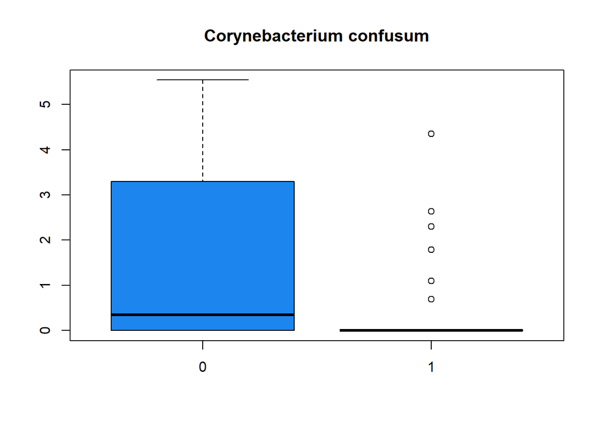

```r
boxplot(test0,test1,names=c("0","1"),
        main=selectVar(res_splsda, comp = 1)$name[2],col=c("dodgerblue2","darkorange"))
```

```r
#cim(res_splsda, row.sideColors = color.mixo(group_virus_EN),row.names = clean_id_EN)
```